# Trajectory slicing: Example 4 - clustering (part 1)

In this example we use the cylindrical slices to cluster trajectories together.

##used libraries

```r
library(tidyr)#for crunching
library(magrittr)
library(dplyr)#for crunching
library(data.table)#for crunching (specifically rbindlist, which is fast).
library(circular)#for circular variables (the angle) and circular means
library(tictoc)#for time keeping
library(ggplot2)#for plotting
library(rgdal)#for maps
library(scales)#for plotting
library(maps)#for the map

library(trajectory.slicing)

#In case you have problems with getting a compiled trajectory.slicing library and with getting it compiled yourself, you can also directly source the needed custom functions by uncommenting what is below.
#source(paste0(here::here(),"/../trajectory-slicing-Rpackage/package_code/R/fun_get_polar_coords_geographical.R"))
#source(paste0(here::here(),"/../trajectory-slicing-Rpackage/package_code/R/fun_get_slice_crossing_df.R"))
#source(paste0(here::here(),"/../trajectory-slicing-Rpackage/package_code/R/fun_create_radial_guide_df.R"))
#some world maps


world_with_borders = map_data("world")
#world_without_borders = readRDS(paste0(here::here(),"/miscellaneous/worldmap_continents.rds")) #a worldmap without country borders that I've created
```

##data import and prepping

```r
set.seed(1000)
#myHYS_E3 = readRDS("D:/slices.of.HYSPLIT_V2/slices.of.HYSPLIT/data/DARWIN_back_20d_run1/df/run_combined.rds")%>%

#myHYS_E3=readRDS("D:/slices.of.HYSPLIT_V2/slices.of.HYSPLIT/data/Maido_back_4d/run_combined.rds")%>%
#myHYS_E3=readRDS("D:/slices.of.HYSPLIT_V2/slices.of.HYSPLIT/data/Mace_Head_back4d/run_combined.rds")%>%
myHYS_E4=readRDS(paste0(here::here(),"/example_data/Mace_Head_back4d/run_combined.rds"))%>%
#myHYS_E4=readRDS("D:/slices.of.HYSPLIT_V2/slices.of.HYSPLIT/data/V1_Cape_Point_5d/df/run_combined.rds")%>%
#myHYS_E4=readRDS("D:/slices.of.HYSPLIT_V2/slices.of.HYSPLIT/data/V1_Chacaltaya_2015-2018/df/run_combined.rds")%>%
  dplyr::mutate(get_polar_coords_geographical(lat,lon,lat_i,lon_i),.after=lon)%>%

  #as I'm emitting trajectories from one single point of emission, the time of emission is unique to each trajectory. I'm using it as ID here.
  dplyr::mutate(ID = traj_dt_i)%>%
  #dplyr::filter(ID %in% sample(unique(.$ID), size = 3000))%>%
  {.}

#estimating how much difference in latitude, longitude, and radius can be expected in one time step.
#This is used to defined the "delta_filter" later. The goal is to save computational time.
delta_filter_estimate = myHYS_E4 %>%
  dplyr::group_by(ID)%>%
  dplyr::arrange(hour_along)%>%
  dplyr::summarise(across(.cols = c("radius","lat","lon"), .fns = function(x){abs(x-lag(x,1))}, .names = "{.col}_delta"))%>%
  dplyr::ungroup()%>%
  dplyr::summarise_at(vars(contains("delta")), function(x){quantile(x, 0.99,na.rm=TRUE)})

#delta_filter_estimate
```

##computing the radial slices.

```r
slice_positions = seq(0.5,15,2)
tic()
sliced_df_CHC= data.table::rbindlist(lapply(slice_positions,
                                                function(x){get_slice_crossing_df(traj_df=myHYS_E4, slice_position = x,
                                                                                  slice_type="radial",
                                                                                  ID_columns = "ID",
                                                                                  extra_vars = c("lat","lon","height","mixdepth"),
                                                                                  delta_filter = delta_filter_estimate$radius_delta[1])}))%>%
  #the following column allows us to plot the angle with 0 (-> north) in the middle. This is usally more intuitive
  dplyr::mutate(angle_wmean_Nmid = ifelse(angle_wmean <=180, angle_wmean, angle_wmean-360))
toc()
```

```
## 158.88 sec elapsed
```

```r
#dataframe for the "radial legend" in the plots
radial_slice_df = create_radial_guide_df(slice_radius=slice_positions,lat_center = myHYS_E4$lat_i[1], lon_center = myHYS_E4$lon_i[1])
```

Lets cluster trajectories based on where they crossed the cylindrical slices. First we have to get data into an adequate format. For starters, we need to consider only ONE crossing of each slice per trajectory. (Remember that a trajectory can theoretically cross a slice several times). As representative crossing, we will take the last crossing before the trajectory arrives at the station. Then, we will transform the data into “wide format”

```r
sliced_df_CHC_last = sliced_df_CHC %>%
  dplyr::group_by(ID, slice_position)%>%
  #dplyr::arrange(ID,slice_position,hour_along_wmean)%>%
  dplyr::filter(hour_along_wmean == max(hour_along_wmean))%>% # getting the last crossing per slice. Note that the "maximum" is calculated for each group (defined by ID and slice position) separately
  dplyr::ungroup()


#The sliced data is in long format (many rows, few columns). We need a wide format (few rows, many columns) for clustering.

sliced_df_CHC_last_wide = sliced_df_CHC_last %>%
  dplyr::select(ID, slice_position, angle_wmean)%>%
  tidyr::pivot_wider(id_cols = "ID", names_from = slice_position, values_from = c("angle_wmean"),
                     names_glue= "{slice_position}__{.value}")%>%
  dplyr::arrange(ID)%>%
  na.omit() #NAs are bad for clustering. In essence, this na.omit means that we're only taking the trajectory that crossed each slice at least once.


head(sliced_df_CHC_last_wide)
```

| ID | 0.5__angle_wmean | 2.5__angle_wmean | 4.5__angle_wmean | 6.5__angle_wmean | 8.5__angle_wmean | 10.5__angle_wmean | 12.5__angle_wmean | 14.5__angle_wmean |
| --- | --- | --- | --- | --- | --- | --- | --- | --- |
| 2017-01-01 00:00:00 | 332.383082 | 319.870151 | 309.5360 | 302.6084 | 298.2048 | 294.9887 | 292.4479 | 290.1853 |
| 2017-01-01 01:00:00 | 337.762385 | 322.584768 | 311.2013 | 303.8147 | 299.0597 | 295.6475 | 293.0578 | 290.8392 |
| 2017-01-01 02:00:00 | 348.324241 | 327.861314 | 314.3391 | 305.9347 | 300.6097 | 296.6323 | 293.8223 | 291.5100 |
| 2017-01-01 03:00:00 | 359.163160 | 336.475251 | 319.8200 | 309.6982 | 303.3768 | 298.8350 | 295.5496 | 292.9606 |
| 2017-01-01 04:00:00 | 9.739547 | 348.040212 | 328.0529 | 315.7293 | 307.8614 | 302.6928 | 298.8635 | 296.0689 |
| 2017-01-01 05:00:00 | 18.591787 | 1.062243 | 338.4952 | 322.3954 | 312.3279 | 305.7759 | 301.3498 | 298.0341 |

##preparing a matrix for clustering.  
As we’re clustering based on an angle, we have to deal with the discontinuity at 0 degrees (0 and 360 is the same direction). We can do this by rotating the angle gradually from 0 to 360 degrees and including this as new columns. This way, all trajectories are affected similarly by the discontinuity (and not only trajectories close to 0 degrees), so that the discontinuity doesn’t bias the clustering results.  
Note that this method increases quite importantly the number of columns to be clustered (and thus affects computational time), but kmeans is a fast and efficient algorithm, so it usually doesn’t really matter.

```r
angle_shifts = seq(0,359,5)#rotating from 0 to 360 degrees, in steps of a few degrees.

k_list = list()
for (i in 1:length(angle_shifts)){
  k_list[[i]] = sliced_df_CHC_last_wide %>%
    dplyr::select(!ID)%>% #we don't want to cluster on the ID column
    dplyr::rename_at(vars(contains("angle")), function(x){paste0("V",i,"_",x)})%>%
    dplyr::mutate_at(vars(contains("angle")), function(x){(x+angle_shifts[i])%%360})
}
myk_all = do.call(cbind, k_list)%>%
  as.matrix()
```

##lets use the ellbow mode to evaluate what number of clusters might be appropiate.

```r
set.seed(66)
k.min = 1
k.max = 12
data = myk_all[sample(1:nrow(myk_all), 2000),] #I'm using a sample of all rows for the ellbow method to save computational time.
wss = sapply(k.min:k.max,
              function(k){kmeans(data, k)$tot.withinss})
wss
```

```
##  [1] 8888490361 6750890287 5317081271 4616572943 4104311452 3788422164
##  [7] 3663421388 3421216466 3298323008 3172088040 3133143598 2984022462
```

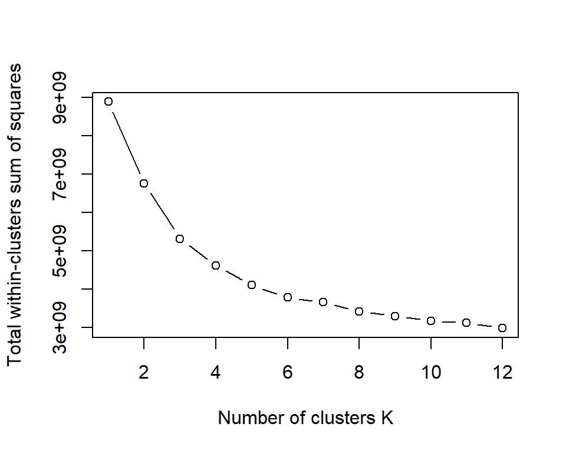

```r
plot(k.min:k.max, wss,
     type="b", pch = 1,
     xlab="Number of clusters K",
     ylab="Total within-clusters sum of squares")
```

```r
library(factoextra)
```

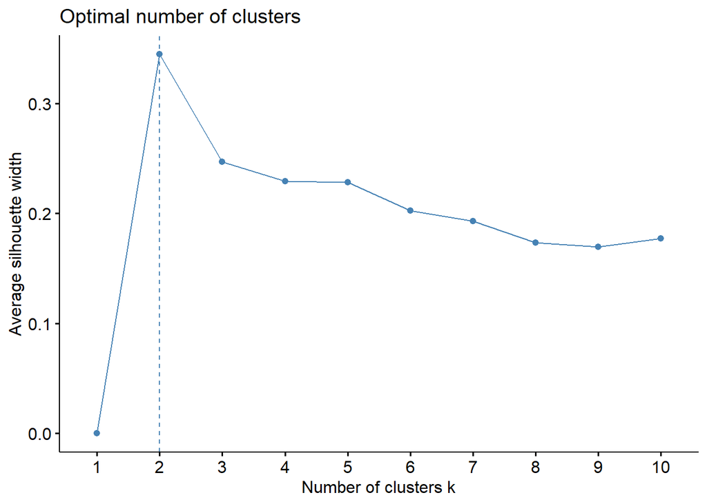

```r
fviz_nbclust(data, kmeans, method='silhouette')
```

##Now performing the k means clustering and assigning the right cluster to each trajectory ID

```r
set.seed(42)
myclustering = kmeans(myk_all, centers = 5)

clus_IDs = sliced_df_CHC_last_wide %>%
  dplyr::mutate(cluster = myclustering$cluster)%>%
  dplyr::select(ID, cluster)
```

##plotting trajectory plots to visualize the clusters. As plotting ALL trajectories will take forever, I just take a random and appropiately sized subsample of all trajectories.

```r
set.seed(42)
myHYS_sample = myHYS_E4 %>%
  dplyr::full_join(., clus_IDs)%>%
  dplyr::filter(ID %in% sample(unique(myHYS_E4$ID), size = 300))%>%
  dplyr::filter(!is.na(cluster))%>%
  dplyr::mutate(cluster=as.character(cluster))
```

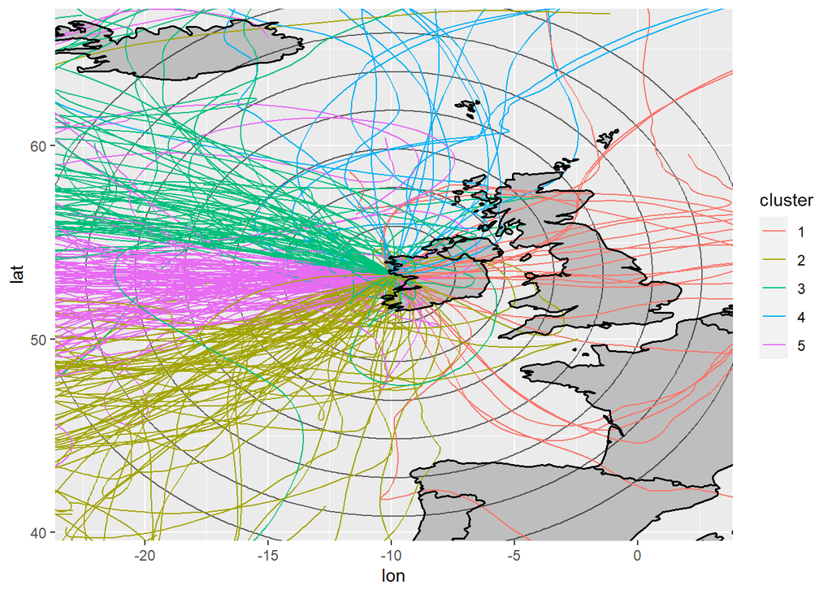

```r
ggplot(myHYS_sample, aes(x=lon, y = lat, colour=cluster, group=ID))+
  geom_polygon(data = world_with_borders, aes(x=long, y=lat, group=group), color='transparent', fill="gray", inherit.aes=FALSE)+
  geom_path(data=radial_slice_df, aes(x=lon, y = lat, group=slice_position), inherit.aes=FALSE, alpha=0.6)+
  geom_path()+
  geom_path(data = world_with_borders, aes(x=long, y=lat, group=group), color='black', linewidth=0.7, inherit.aes=FALSE)+
  coord_cartesian(xlim = myHYS_E4$lon_i[1]+12.5*c(-1,1), ylim =myHYS_E4$lat_i[1]+12.5*c(-1,1))
```

In the above plot we see that the clustering appears to work well, but that some trajectories criss-cross all over the place. This is because these trajectories may cross some slices more than once (remember: We only took the last slice crossing to compute the clustering). To only take the “purest” trajectories, we can exclude those trajectories that crossed any slice more than once.

```r
#getting a vector of all trajectories that crossed at least one slice more than once
IDs_multicross = sliced_df_CHC%>%
  dplyr::group_by(ID, slice_position)%>%
  dplyr::summarise(numb = sum(!is.na(angle_wmean)))%>%
  dplyr::filter(numb > 1)%>%
  pull(ID)%>% unique()
```

[output not shown]

```r
#what fraction of all trajectories crossed a slice more than once?
print(paste0("The fraction of trajectories that crossed at least one slice more than once is: ",
             signif(length(IDs_multicross)/length(unique(sliced_df_CHC$ID)),3)))
```

```
## [1] "The fraction of trajectories that crossed at least one slice more than once is: 0.269"
```

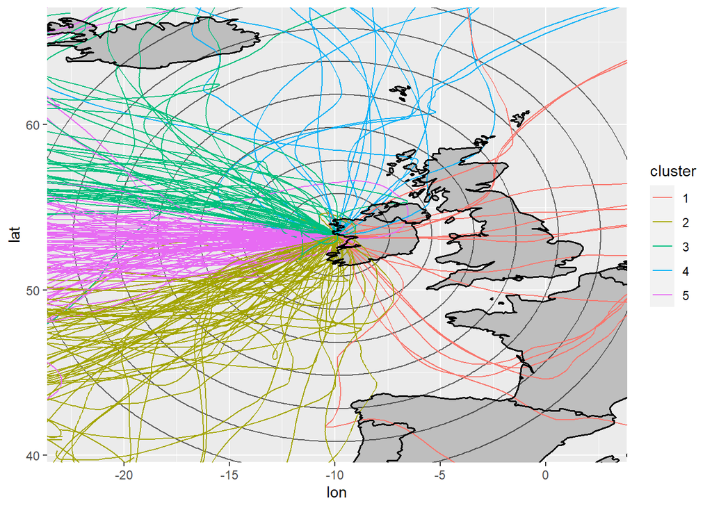

```r
#redoing the plot, but this time excluding "multicross" IDs.
ggplot(myHYS_sample %>% dplyr::filter(!(ID %in% IDs_multicross)),
       aes(x=lon, y = lat, colour=cluster, group=ID))+
  geom_polygon(data = world_with_borders, aes(x=long, y=lat, group=group), color='transparent', fill="gray", inherit.aes=FALSE)+
  geom_path(data=radial_slice_df, aes(x=lon, y = lat, group=slice_position), inherit.aes=FALSE, alpha=0.6)+
  geom_path()+
  geom_path(data = world_with_borders, aes(x=long, y=lat, group=group), color='black', linewidth=0.7, inherit.aes=FALSE)+
  coord_cartesian(xlim = myHYS_E4$lon_i[1]+12.5*c(-1,1), ylim =myHYS_E4$lat_i[1]+12.5*c(-1,1))
```

```r
myHYS_E4.foot = myHYS_E4 %>%
  dplyr::full_join(., clus_IDs)%>%
  #dplyr::filter(!(ID %in% IDs_multicross))%>%
  dplyr::mutate(lat_cut = cut(lat, seq(-90,90,0.5)),
                lon_cut = cut(lon, seq(-180,180,0.5)))%>%
  dplyr::group_by(cluster, lat_cut, lon_cut)%>%
  dplyr::summarise(sum = sum(!is.na(height)),
                   radmean = mean(radius,na.rm=TRUE))%>%
  dplyr::mutate(get_interval_bounds(lat_cut, "lat"),
                get_interval_bounds(lon_cut, "lon"))%>%
  dplyr::group_by(cluster)%>%
  dplyr::mutate(sum_times_rad = sum*radmean,
                sum_rad_norm = sum_times_rad/max(sum_times_rad,na.rm=TRUE),
                sum_norm = sum/max(sum,na.rm=TRUE))
myHYS_E4.foot_filtered = myHYS_E4 %>%
  dplyr::full_join(., clus_IDs)%>%
  dplyr::filter(!(ID %in% IDs_multicross))%>%
  dplyr::mutate(lat_cut = cut(lat, seq(-90,90,0.5)),
                lon_cut = cut(lon, seq(-180,180,0.5)))%>%
  dplyr::group_by(cluster, lat_cut, lon_cut)%>%
  dplyr::summarise(sum = sum(!is.na(height)),
                   radmean = mean(radius,na.rm=TRUE))%>%
  dplyr::mutate(get_interval_bounds(lat_cut, "lat"),
                get_interval_bounds(lon_cut, "lon"))%>%
  dplyr::group_by(cluster)%>%
  dplyr::mutate(sum_times_rad = sum*radmean,
                sum_rad_norm = sum_times_rad/max(sum_times_rad,na.rm=TRUE),
                sum_norm = sum/max(sum,na.rm=TRUE))
```

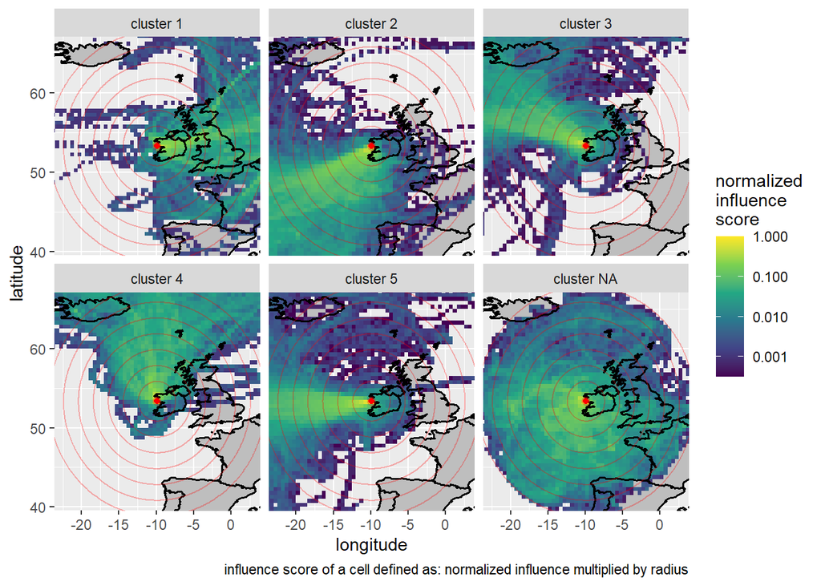

```r
p_footprint_radial = ggplot(data=myHYS_E4.foot,
                            aes(xmin = lon_inf, xmax=lon_sup, ymin =lat_inf, ymax=lat_sup, fill=sum_norm))+
  facet_wrap(~cluster, labeller = labeller(cluster = function(x){paste0("cluster ",x)}))+
  geom_polygon(data = world_with_borders, aes(x=long, y=lat, group=group), color='transparent', fill="gray", inherit.aes=FALSE)+
  geom_rect()+
  geom_path(data = world_with_borders, aes(x=long, y=lat, group=group), color='black', linewidth=0.7, inherit.aes=FALSE)+
  geom_path(data=radial_slice_df, aes(x=lon, y = lat, group=slice_position), inherit.aes=FALSE, alpha=0.3, col="red")+
  annotate(geom="point", x = myHYS_E4$lon_i[1], y = myHYS_E4$lat_i[1], colour="red")+
  scale_fill_viridis_c(trans="log10",  oob=squish)+
  coord_cartesian(xlim = myHYS_E4$lon_i[1]+12.5*c(-1,1), ylim = myHYS_E4$lat_i[1]+12.5*c(-1,1))+
  labs(x="longitude", y = "latitude", fill = "normalized\ninfluence\nscore",
       caption="influence score of a cell defined as: normalized influence multiplied by radius")


p_footprint_radial_filtered = ggplot(data=myHYS_E4.foot_filtered,
       aes(xmin = lon_inf, xmax=lon_sup, ymin =lat_inf, ymax=lat_sup, fill=sum_norm))+
  facet_wrap(~cluster, labeller = labeller(cluster = function(x){paste0("cluster ",x)}))+
  geom_polygon(data = world_with_borders, aes(x=long, y=lat, group=group), color='transparent', fill="gray", inherit.aes=FALSE)+
  geom_rect()+
  geom_path(data = world_with_borders, aes(x=long, y=lat, group=group), color='black', linewidth=0.7, inherit.aes=FALSE)+
  geom_path(data=radial_slice_df, aes(x=lon, y = lat, group=slice_position), inherit.aes=FALSE, alpha=0.3, col="red")+
  annotate(geom="point", x = myHYS_E4$lon_i[1], y = myHYS_E4$lat_i[1], colour="red")+
  scale_fill_viridis_c(trans="log10",  oob=squish)+
  coord_cartesian(xlim = myHYS_E4$lon_i[1]+12.5*c(-1,1), ylim = myHYS_E4$lat_i[1]+12.5*c(-1,1))+
  labs(x="longitude", y = "latitude", fill = "normalized\ninfluence\nscore",
       caption="influence score of a cell defined as: normalized influence multiplied by radius")

p_footprint_radial
```

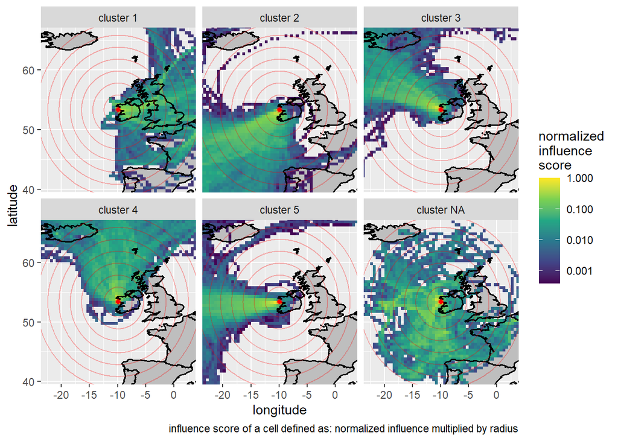

```r
p_footprint_radial_filtered
```

#how does the clustering look like in “slice space”?

```r
sliced_df_CHC_last_clus = sliced_df_CHC_last %>%
  dplyr::full_join(., clus_IDs)%>%
  dplyr::filter(!(ID %in% IDs_multicross),
                !is.na(cluster)) #filtering out trajectories that didn't cross all slices
```

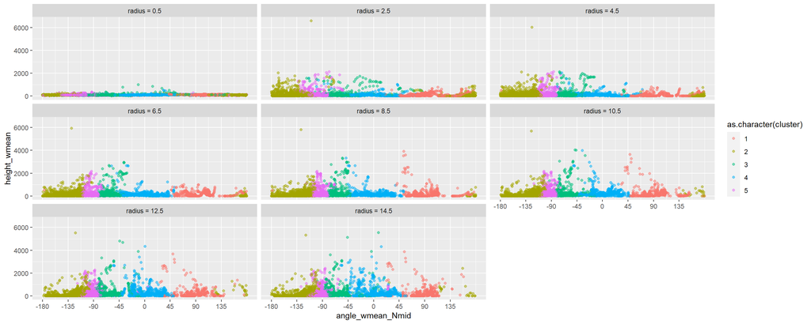

```r
ggplot(sliced_df_CHC_last_clus, aes(x=angle_wmean_Nmid, colour=as.character(cluster), y = height_wmean))+
  geom_point(alpha = 0.5)+
  #coord_polar(direction = -1)+
  scale_x_continuous(breaks = seq(-180,179,45), limits = c(-180,180))+
  facet_wrap(~slice_position, labeller = labeller(slice_position = function(x){paste0("radius = ",x)}))
```

##visualizing cluster centers  
It is also interesting to calculate the cluster centers in cylindrical slice space. As a mean of dispersion, I also calculate the inter-quartile-range for the angle and height of slice crossing for each radius and cluster. Don’t forget to use circular functions for circular variables!

```r
slice_clus_centers =sliced_df_CHC_last_clus %>%
  dplyr::group_by(cluster, slice_position)%>%
  dplyr::summarise(angle_median = median.circular(angle_wmean),
                   angle_lower = quantile.circular(angle_wmean, probs = 0.25, na.rm=TRUE),
                   angle_upper = quantile.circular(angle_wmean, probs = 0.75, na.rm=TRUE),
                   height_median = median(height_wmean),
                   height_lower = quantile(height_wmean, 0.25,na.rm=TRUE),
                   height_upper = quantile(height_wmean, 0.75, na.rm=TRUE))%>%
  dplyr::mutate(cluster=factor(cluster))
```

and visualizing these centers. Note that I’m visualizing the height of the clustered trajectories as well, even though it didn’t influence the clustering.

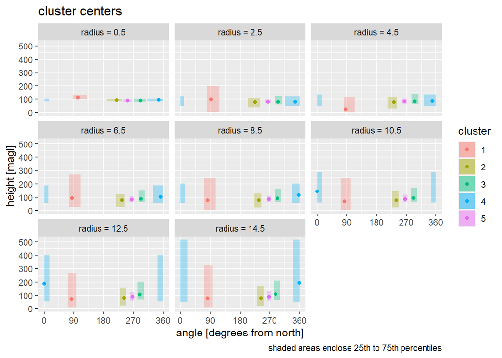

```r
#I want to plot errorbars. There is one pesky thing to address: If the errorbar crossed the discontinuity at 0/360 degrees, this will
#lead to weird artifacts. To fix this, I'm gonna plot 2 different data frames adjusted for this issue.
errorbar_frame_1 = slice_clus_centers %>%
  dplyr::mutate(angle_upper = ifelse(angle_upper < angle_lower, 360, angle_upper))
errorbar_frame_2 =  slice_clus_centers %>%
  dplyr::filter(angle_upper < angle_lower)%>%
  dplyr::mutate(angle_lower = 0)


ggplot(slice_clus_centers, aes(x=angle_median, y = height_median, colour = cluster ))+
  #geom_errorbar(aes(ymin = height_lower, ymax = height_upper))+
  geom_rect(data=errorbar_frame_1, aes(xmin = angle_lower, xmax=angle_upper, ymin = height_lower, ymax=height_upper, fill=cluster),alpha=0.3, linetype=0)+
  geom_rect(data=errorbar_frame_2, aes(xmin = angle_lower, xmax=angle_upper, ymin = height_lower, ymax=height_upper, fill=cluster),alpha=0.3, linetype=0)+
  #geom_errorbarh(data=errorbar_frame_1,aes(xmin = angle_lower, xmax = angle_upper))+
  #geom_errorbarh(data=errorbar_frame_2,aes(xmin = angle_lower, xmax = angle_upper))+
    geom_point()+
  #coord_polar()+
  scale_x_continuous(breaks = seq(0,360,90), limits = c(0,360))+
  facet_wrap(~slice_position, labeller = labeller(slice_position = function(x){paste0("radius = ",x)}))+
  labs(y = "height [magl]", x = "angle [degrees from north]", title = "cluster centers",
       caption = "shaded areas enclose 25th to 75th percentiles")
```

##I’ll perform a tradiational “lat-lon” clustering for comparison

```r
##ordering the df
myHYS_E4_sel = myHYS_E4%>%
  dplyr::select(ID,hour_along, lat, lon)%>%
  dplyr::arrange(ID, hour_along)

##pivoting it wider, so that each ID is its own row
myHYS_E4_sel_wide = myHYS_E4_sel %>%
  dplyr::group_by(ID)%>%
  #dplyr::select(ID, slice_position, angle_wmean)%>%
  tidyr::pivot_wider(id_cols = "ID", names_from = hour_along, values_from = c("lon","lat"),
                     names_glue= "{hour_along}__{.value}")%>%
  dplyr::ungroup()


set.seed(42)
myclustering_latlon = kmeans(myHYS_E4_sel_wide %>%dplyr::select(!ID)%>% as.matrix(), centers = 5)

clus_IDs_latlon = myHYS_E4_sel_wide %>%
  dplyr::ungroup()%>%
  dplyr::mutate(cluster = myclustering_latlon$cluster)%>%
  dplyr::select(ID, cluster)
```

```r
latlon_clustered.foot = myHYS_E4_sel %>%
  dplyr::full_join(.,clus_IDs_latlon)%>%
  #dplyr::filter(!(ID %in% IDs_multicross))%>%
  #dplyr::full_join(., clus_IDs)%>%
  dplyr::mutate(lat_cut = cut(lat, seq(-90,90,0.5)),
                lon_cut = cut(lon, seq(-180,180,0.5)))%>%
  dplyr::group_by(cluster, lat_cut, lon_cut)%>%
  dplyr::summarise(sum = sum(!is.na(lat)),
                   #radmean = mean(radius,na.rm=TRUE)
                   )%>%
  dplyr::mutate(get_interval_bounds(lat_cut, "lat"),
                get_interval_bounds(lon_cut, "lon"))%>%
  dplyr::group_by(cluster)%>%
  dplyr::mutate(#sum_times_rad = sum*radmean,
              #  sum_rad_norm = sum_times_rad/max(sum_times_rad,na.rm=TRUE),
                sum_norm = sum/max(sum,na.rm=TRUE)
    )
```

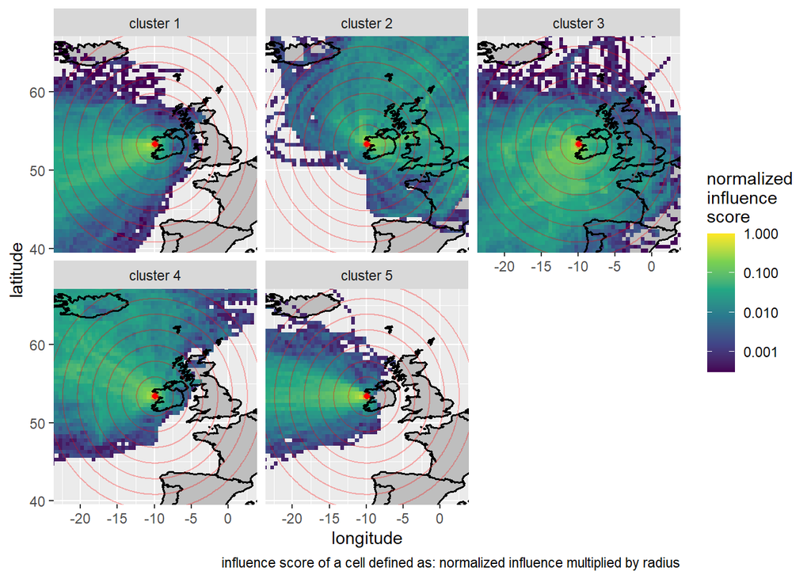

```r
p_footprint_latlon = ggplot(latlon_clustered.foot  %>% dplyr::filter(!is.na(cluster)), #not showing "NA" cluster, which corresponds to trajectories that did not cross any of the slices
                            aes(xmin = lon_inf, xmax=lon_sup, ymin =lat_inf, ymax=lat_sup, fill=sum_norm))+
  facet_wrap(~cluster, labeller = labeller(cluster = function(x){paste0("cluster ",x)}))+
  geom_polygon(data = world_with_borders, aes(x=long, y=lat, group=group), color='transparent', fill="gray", inherit.aes=FALSE)+
  geom_rect()+
  geom_path(data = world_with_borders, aes(x=long, y=lat, group=group), color='black', linewidth=0.7, inherit.aes=FALSE)+
  annotate(geom="point", x = myHYS_E4$lon_i[1], y = myHYS_E4$lat_i[1], colour="red")+
  geom_path(data=radial_slice_df, aes(x=lon, y = lat, group=slice_position), inherit.aes=FALSE, alpha=0.3, col="red")+
  scale_fill_viridis_c(trans="log10",  oob=squish)+
  coord_cartesian(xlim = myHYS_E4$lon_i[1]+12.5*c(-1,1), ylim = myHYS_E4$lat_i[1]+12.5*c(-1,1))+
  labs(x="longitude", y = "latitude", fill = "normalized\ninfluence\nscore",
       caption="influence score of a cell defined as: normalized influence multiplied by radius")

p_footprint_latlon
```

#how many trajectories were clustered? If filtering was applied, how many trajectories were lost?

```r
length_all = myHYS_E4 %>% pull(ID)%>%unique()%>%length()

length_latlon_clus = myHYS_E4 %>% pull(ID)%>% unique() %>% length()

length_radial_all = myHYS_E4 %>%
  dplyr::full_join(., clus_IDs)%>%
  pull(ID)%>%unique()%>%length()
length_radial_filtered = myHYS_E4 %>%
  dplyr::full_join(., clus_IDs)%>%
  dplyr::filter(!(ID %in% IDs_multicross))%>%
  #dplyr::filter(!is.na(cluster))%>%
  pull(ID)%>%unique()%>%length()
xlims = myHYS_E4$lon_i[1]+15*c(-1,1)
ylims = myHYS_E4$lat_i[1]+15*c(-1,1)

p_footprint_latlon +
  coord_cartesian(xlim = xlims, ylim = ylims)+
  labs(title = "kmeans based on latitude & longitude",subtitle = paste0("n = ", length_latlon_clus))
```

[output not shown]

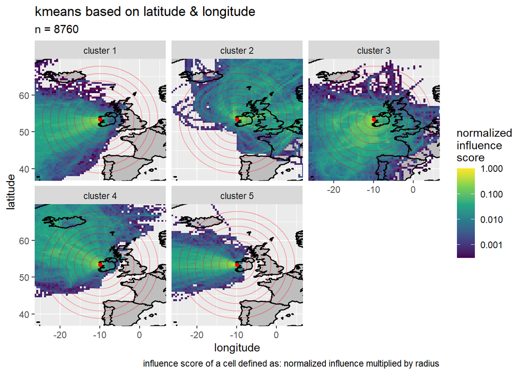

```r
p_footprint_radial +
  coord_cartesian(xlim = xlims, ylim = ylims)+
  labs(title = "kmeans based on angle (radial slices)", subtitle = paste0("n = ", length_radial_all))
```

[output not shown]

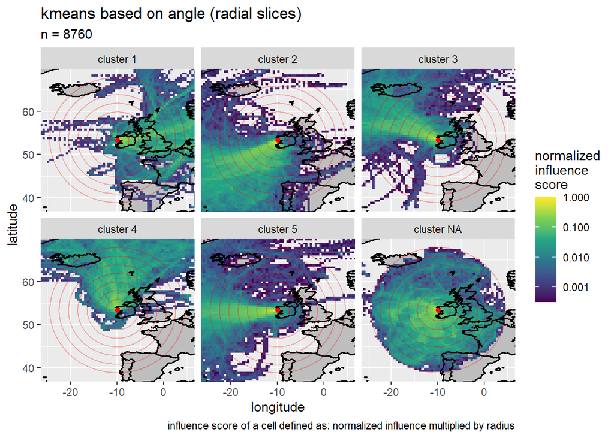

```r
p_footprint_radial_filtered + coord_cartesian(xlim = xlims, ylim = ylims)+
  labs(title = "kmeans based on angle (radial slices); multicrosses excluded",
                                   subtitle = paste0("n = ", length_radial_filtered))
```

[output not shown]

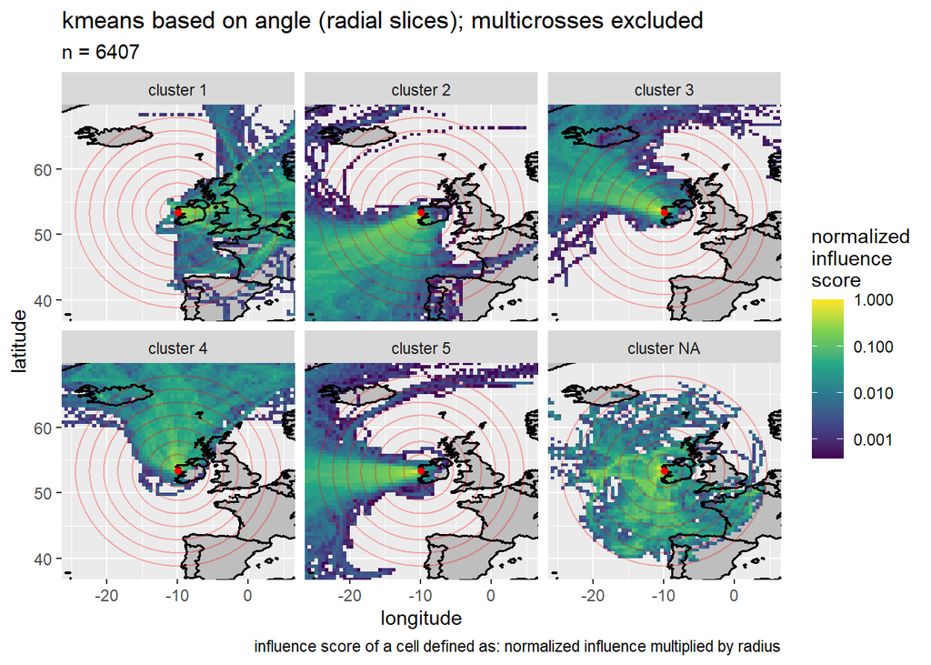

It is interesting to compare these clustering techniques. Cleanest separation, within the range of considered radii, appears to be obtained upon cylindrical clustering and filtering out of “multicross” trajectories. However, some trajectories are lost this way (~25%).